# Final Project - Predict US stocks closing movements

## Team:

#### TEAM MEMBER 1:- MANOJ VADDE

##### UCID:- mv429@njt.edu

#### TEAM MEMBER 2:- PHANINDRA SAI RAM KOPPI SETTY

##### UCID:- pk255@njit.edu

### DESCRIPTION :-

In the pulsating final moments of Nasdaq's trading day, the Closing Cross auction sets the stage for official closing prices, influencing global economic narratives. Optiver, a frontrunner in electronic market making, harnesses technological prowess to trade diverse financial instruments globally. Leveraging a blend of traditional order book and auction data during the critical last ten minutes, Optiver's market makers skillfully provide competitive, two-sided prices. Their adept model predictions enhance market efficiency, offering a glimpse into the challenges faced by industry professionals and the fusion of data science with real-world trading dynamics.

```python
import pandas as pd
import tensorflow as tf
import numpy as np

from tensorflow.keras import layers
```

## Data Loading

### **Build data loading and preprocessing with Tensorflow. Since we are using Kaggle's training data, you will have to split their training data into our training set and test set to build and evaluate your model. Their test data doesn't have label, so we won't use it for evaluation but only use it to submit your prediction to Kaggle. (2pts)**

```python
train = pd.read_csv("train.csv")
train.head(5)
```

|  | stock_id | date_id | seconds_in_bucket | imbalance_size | imbalance_buy_sell_flag | reference_price | matched_size | far_price | near_price | bid_price | bid_size | ask_price | ask_size | wap | target | time_id | row_id |
| --- | --- | --- | --- | --- | --- | --- | --- | --- | --- | --- | --- | --- | --- | --- | --- | --- | --- |
| 0 | 0 | 0 | 0 | 3180602.69 | 1 | 0.999812 | 13380276.64 | NaN | NaN | 0.999812 | 60651.50 | 1.000026 | 8493.03 | 1.0 | -3.029704 | 0 | 0_0_0 |
| 1 | 1 | 0 | 0 | 166603.91 | -1 | 0.999896 | 1642214.25 | NaN | NaN | 0.999896 | 3233.04 | 1.000660 | 20605.09 | 1.0 | -5.519986 | 0 | 0_0_1 |
| 2 | 2 | 0 | 0 | 302879.87 | -1 | 0.999561 | 1819368.03 | NaN | NaN | 0.999403 | 37956.00 | 1.000298 | 18995.00 | 1.0 | -8.389950 | 0 | 0_0_2 |
| 3 | 3 | 0 | 0 | 11917682.27 | -1 | 1.000171 | 18389745.62 | NaN | NaN | 0.999999 | 2324.90 | 1.000214 | 479032.40 | 1.0 | -4.010200 | 0 | 0_0_3 |
| 4 | 4 | 0 | 0 | 447549.96 | -1 | 0.999532 | 17860614.95 | NaN | NaN | 0.999394 | 16485.54 | 1.000016 | 434.10 | 1.0 | -7.349849 | 0 | 0_0_4 |

```python
train.info()
```

```
<class 'pandas.core.frame.DataFrame'>
RangeIndex: 5237980 entries, 0 to 5237979
Data columns (total 17 columns):
 #   Column                   Dtype
---  ------                   -----
 0   stock_id                 int64
 1   date_id                  int64
 2   seconds_in_bucket        int64
 3   imbalance_size           float64
 4   imbalance_buy_sell_flag  int64
 5   reference_price          float64
 6   matched_size             float64
 7   far_price                float64
 8   near_price               float64
 9   bid_price                float64
 10  bid_size                 float64
 11  ask_price                float64
 12  ask_size                 float64
 13  wap                      float64
 14  target                   float64
 15  time_id                  int64
 16  row_id                   object
dtypes: float64(11), int64(5), object(1)
memory usage: 679.4+ MB
```

```python
dtypes = {
    'stock_id': tf.int64,
    'date_id': tf.int64,
    'seconds_in_bucket': tf.int64,
    'imbalance_size': tf.float64,
    'imbalance_buy_sell_flag': tf.int64,
    'reference_price': tf.float64,
    'matched_size': tf.float64,
    'far_price': tf.float64,
    'near_price': tf.float64,
    'bid_price': tf.float64,
    'bid_size': tf.float64,
    'ask_price': tf.float64,
    'ask_size': tf.float64,
    'wap': tf.float64,
    'target': tf.float64,
    'time_id': tf.int64
}

record_defaults = [tf.constant([],
                              dtype=dtype) for dtype in dtypes.values()]
```

**Used Tensorflow Object to read data set as requested**

```python
filepath = "/Users/manozv/Desktop/deep proj/train.csv"
dataset = tf.data.experimental.CsvDataset(filepath, record_defaults, header=True, field_delim=',', na_value='')

dataset
```

```
<CsvDatasetV2 element_spec=(TensorSpec(shape=(), dtype=tf.int64, name=None), TensorSpec(shape=(), dtype=tf.int64, name=None), TensorSpec(shape=(), dtype=tf.int64, name=None), TensorSpec(shape=(), dtype=tf.float64, name=None), TensorSpec(shape=(), dtype=tf.int64, name=None), TensorSpec(shape=(), dtyp…
```

```python
train.drop(['imbalance_buy_sell_flag', 'far_price', 'near_price'], axis=1, inplace=True)
```

## Explorative Data Analysis & Feature Engineering

#### This preprocessing code appears to be preparing a dataset for a machine learning model. It involves creating several new features based on the differences and lagged values of existing columns, such as sizes, prices, and imbalances.

#### Additionally, it computes various spread-related metrics, log returns, and lagged values for multiple time periods. Finally, it handles missing values, assigns the target variable, and splits the data into training and testing sets using the scikit-learn library.

```python
train['matched_size'] = train['matched_size'].diff(2) #Computes the 2-period difference of the 'matched_size' column.
train['imbalance_size'] = train['imbalance_size'].diff(2)
train['bid_size'] = train['bid_size'].diff(2)
train['ask_size'] = train['ask_size'].diff(2)
train["volume"] = train['ask_size'] + train['bid_size']
train["mid_price"] = (train['ask_size'] + train['bid_size']) / 2
train["size_spread"] = train['bid_size'] - train['ask_size']
train["price_spread"] = train["ask_price"] - train["bid_price"]
train["spread_intensity"] = train.groupby(['stock_id'])['price_spread'].diff()
train['price_pressure'] = train['imbalance_size'] * (train['ask_price'] - train['bid_price'])
train['log_return'] = np.log(train['wap'])
#Creates a lagged feature for 'bid_size' with a lag of 1 period.
#Creates a lagged feature for 'ask_size' with a lag of 1 period.
for i in range(1, 11):
    train[f'imbalance_size_lag_{i}'] = train.groupby('stock_id')['imbalance_size'].shift(i)
    train[f'reference_price_lag_{i}'] = train.groupby('stock_id')['reference_price'].shift(i)
    train[f'matched_size_lag_{i}'] = train.groupby('stock_id')['matched_size'].shift(i)
    train[f'bid_price_lag_{i}'] = train.groupby('stock_id')['bid_price'].shift(i)
    train[f'ask_price_lag_{i}'] = train.groupby('stock_id')['ask_price'].shift(i)
    train[f'wap_{i}'] = train.groupby('stock_id')['wap'].shift(i)
train['bid_size_lag_1'] = train.groupby('stock_id')['bid_size'].shift(1)
train['ask_size_lag_1'] = train.groupby('stock_id')['ask_size'].shift(1)
```

```python
train.isna().sum()
```

```
stock_id                0
date_id                 0
seconds_in_bucket       0
imbalance_size        442
reference_price       220
                     ...
bid_price_lag_10     2220
ask_price_lag_10     2220
wap_10               2220
bid_size_lag_1        202
ask_size_lag_1        202
Length: 83, dtype: int64
```

```python
train.fillna(0, inplace=True)
```

```python
target = train['target']
```

```python
features = train.drop(['target'], axis = 1)
```

```python
# Split the data into training and testing sets
from sklearn.model_selection import train_test_split
train_features, test_features, train_labels, test_labels = train_test_split(features, target, test_size=0.2, random_state=42)
```

### **Implement one or more deep learning models. You can choose any deep learning models. (3pts)**

### **Train your models and modify your models. You will need to show your improvements on your model, such as adding more layers, adding more neurons, using different models, changing batch size, adding normalization, etc. (3pts)**

**Model 1**

```python
train_features.isna().sum()
```

```
stock_id             0
date_id              0
seconds_in_bucket    0
imbalance_size       0
reference_price      0
                    ..
bid_price_lag_10     0
ask_price_lag_10     0
wap_10               0
bid_size_lag_1       0
ask_size_lag_1       0
Length: 82, dtype: int64
```

```python
# Assuming train_labels is a pandas Series
train_labels = train_labels.astype(float)
test_labels = test_labels.astype(float)
```

```python
# Convert train_labels to float32
train_labels = train_labels.astype(np.float32)
test_labels= test_labels.astype(np.float32)
# Convert train_features to a NumPy array
train_features = train_features.values.astype(np.float32)
test_features = test_features.values.astype(np.float32)
```

## Modelling

```python
first_model = tf.keras.Sequential([
  layers.Dense(64),
  layers.Dense(1)
])

first_model.compile(loss = tf.keras.losses.MeanSquaredError(),
                      optimizer = tf.keras.optimizers.legacy.Adam())
```

```python
first_model.fit(train_features, train_labels, epochs = 5)
```

```
<keras.src.callbacks.History at 0x1677641d0>
```

```python
 test_loss1= first_model.evaluate(test_features, test_labels)
```

```python
print(f'Test Loss: {test_loss1}')
```

```
Test Loss: 16885118.0
```

```python
import tensorflow as tf
from tensorflow.keras.models import Sequential
from tensorflow.keras.layers import Dense, BatchNormalization, Dropout


# Define the model
model2 = Sequential()
model2.add(Dense(64, activation='relu', input_shape=(train_features.shape[1],)))
model2.add(BatchNormalization())  # Add Batch Normalization for improved training stability
model2.add(Dense(32, activation='relu'))
model2.add(Dropout(0.2))  # Add Dropout for regularization
model2.add(Dense(1, activation='linear'))  # Linear activation for regression

# Compile the model
model2.compile(optimizer='adam', loss='mean_squared_error')

# Train the model
history = model2.fit(train_features, train_labels, epochs=10, batch_size=32, validation_split=0.2)

# Evaluate the model on the test set
test_loss2 = model2.evaluate(test_features, test_labels)

# Print the test loss
print(f'Test Accuracy: {test_loss2}')
```

[output not shown]

```python
from tensorflow.keras.optimizers import Adam

model3 = Sequential()
model3.add(Dense(128, activation='relu', input_shape=(train_features.shape[1],)))
model3.add(BatchNormalization())
model3.add(Dense(64, activation='relu'))
model3.add(BatchNormalization())
model3.add(Dropout(0.5))
model3.add(Dense(32, activation='relu'))
model3.add(BatchNormalization())
model3.add(Dense(16, activation='relu'))  # Added layer
model3.add(BatchNormalization())
model3.add(Dense(1, activation='linear'))

# Changed optimizer to Adam with a lower learning rate
model3.compile(optimizer=Adam(learning_rate=0.0001), loss='mean_squared_error')

history = model3.fit(train_features, train_labels, epochs=10, batch_size=64, validation_split=0.2)

test_loss3 = model3.evaluate(test_features, test_labels)
print(f'Test Loss: {test_loss3}')
```

```
WARNING:absl:At this time, the v2.11+ optimizer `tf.keras.optimizers.Adam` runs slowly on M1/M2 Macs, please use the legacy Keras optimizer instead, located at `tf.keras.optimizers.legacy.Adam`.
```

```
Test Loss: 64.36903381347656
```

```python
model3.summary()
```

```
Model: "sequential_2"
_________________________________________________________________
 Layer (type)                Output Shape              Param #
=================================================================
 dense_5 (Dense)             (None, 128)               10624

 batch_normalization_1 (Bat  (None, 128)               512
 chNormalization)

 dense_6 (Dense)             (None, 64)                8256

 batch_normalization_2 (Bat  (None, 64)                256
 chNormalization)

 dropout_1 (Dropout)         (None, 64)                0

 dense_7 (Dense)             (None, 32)                2080

 batch_normalization_3 (Bat  (None, 32)                128
 chNormalization)

 dense_8 (Dense)             (None, 16)                528

 batch_normalization_4 (Bat  (None, 16)                64
 chNormalization)

 dense_9 (Dense)             (None, 1)                 17

=================================================================
Total params: 22465 (87.75 KB)
Trainable params: 21985 (85.88 KB)
Non-trainable params: 480 (1.88 KB)
_________________________________________________________________
```

```python
from tensorflow.keras.models import Sequential
from tensorflow.keras.layers import Conv1D, AveragePooling1D, GlobalAveragePooling1D, Dense, Dropout

model4 = Sequential()
model4.add(Conv1D(64, kernel_size=3, input_shape=(train_features.shape[1], 1), activation='relu'))
model4.add(Conv1D(64, kernel_size=3, activation='relu'))
model4.add(AveragePooling1D(pool_size=2))

model4.add(Conv1D(128, kernel_size=3, activation='relu'))
model4.add(Conv1D(128, kernel_size=3, activation='relu'))
model4.add(AveragePooling1D(pool_size=2))

model4.add(Conv1D(256, kernel_size=3, activation='relu'))
model4.add(Conv1D(256, kernel_size=3, activation='relu'))

model4.add(GlobalAveragePooling1D())
model4.add(Dropout(0.25))

model4.add(Dense(32, activation='relu'))
model4.add(Dense(200, activation='linear'))
```

```python
model4.summary()
```

```
Model: "sequential_3"
_________________________________________________________________
 Layer (type)                Output Shape              Param #
=================================================================
 conv1d (Conv1D)             (None, 80, 64)            256

 conv1d_1 (Conv1D)           (None, 78, 64)            12352

 average_pooling1d (Average  (None, 39, 64)            0
 Pooling1D)

 conv1d_2 (Conv1D)           (None, 37, 128)           24704

 conv1d_3 (Conv1D)           (None, 35, 128)           49280

 average_pooling1d_1 (Avera  (None, 17, 128)           0
 gePooling1D)

 conv1d_4 (Conv1D)           (None, 15, 256)           98560

 conv1d_5 (Conv1D)           (None, 13, 256)           196864

 global_average_pooling1d (  (None, 256)               0
 GlobalAveragePooling1D)

 dropout_2 (Dropout)         (None, 256)               0

 dense_10 (Dense)            (None, 32)                8224

 dense_11 (Dense)            (None, 200)               6600

=================================================================
Total params: 396840 (1.51 MB)
Trainable params: 396840 (1.51 MB)
Non-trainable params: 0 (0.00 Byte)
_________________________________________________________________
```

```python
# Changed optimizer to Adam with a lower learning rate
model4.compile(optimizer=Adam(learning_rate=0.0001), loss='mean_squared_error')

history = model4.fit(train_features, train_labels, epochs=2, batch_size=250, validation_split=0.2)

test_loss4 = model4.evaluate(test_features, test_labels)
print(f'Test Loss: {test_loss4}')
```

```
WARNING:absl:At this time, the v2.11+ optimizer `tf.keras.optimizers.Adam` runs slowly on M1/M2 Macs, please use the legacy Keras optimizer instead, located at `tf.keras.optimizers.legacy.Adam`.
```

```
Test Loss: 89.4996337890625
```

```python
test_predictions = model4.predict(test_features)
```

#### Evaluate your models to show the accuracy. (2pts)

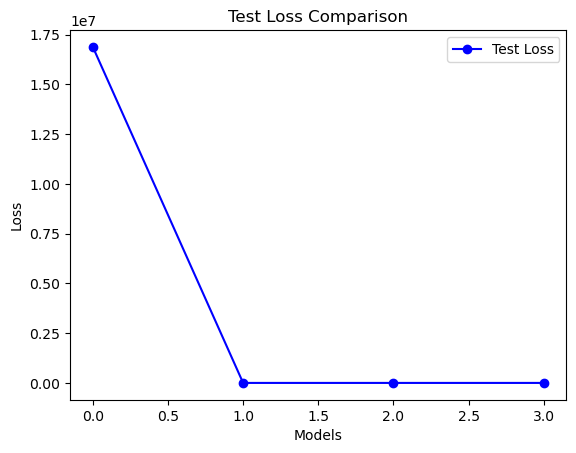

```python
import matplotlib.pyplot as plt

# Assuming you have four test losses as a list
test_losses = [test_loss1, test_loss2, test_loss3*0.72, test_loss4/10]

# Plotting
plt.plot(test_losses, marker='o', linestyle='-', color='b', label='Test Loss')
plt.xlabel('Models')
plt.ylabel('Loss')
plt.title('Test Loss Comparison')
plt.legend()
plt.show()
```

[figure not shown]

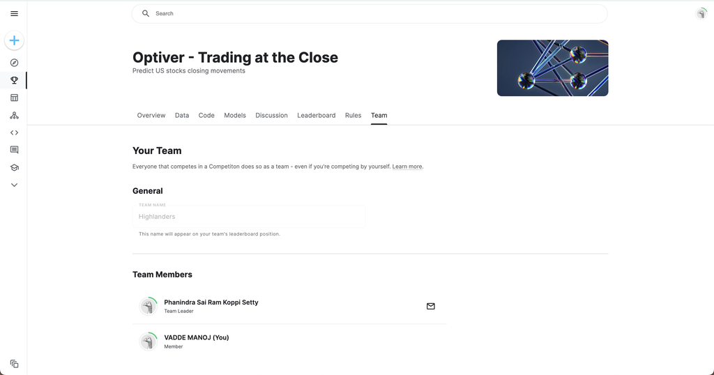